# RQ3

# Final Analysis

**3. What is the maximum likelihood of a customer to select a particular shop?**

**Algorithms selected:** Naive Bayes, decision trees

**Reason for Algorithm Selections:** Naive Bayes is a simple Bayesian supervised classiﬁer that assumes that all attributes are independent of each other.Because of this all attributes can be learned separately which results in faster performance.But its accuracy rate is lesser than that of Decision trees.Decision tree is a type of supervised learning algorithm that can be used in both regression and classification problems.A small change in the data can cause a large change in the final estimated tree.However,they are intuitively very easy to explain. They closely mirror human decision-making compared to other regression and classification approaches.

**Features Selected:** distance_avg,products_purchased_avg,unique_products_purchased_avg,product_price_Avg, amount_purchased_Avg.

**Analysis** **1) Data preparation for classification**

```r
library(caret)
library(dplyr)         # Used by caret
library(kernlab)       # support vector machine
library(pROC)
library(e1071)
library(rpart)
library(readr)
```

```r
library(tidyverse)
library(rpart.plot)
file_path<- "Supermarket_Data_Prediction.csv"
supermarket_data_predict <- read_csv(file_path)
View(supermarket_data_predict)
supermarket_data_predict$most_pref_shop=factor(supermarket_data_predict$most_pref_shop)
str(supermarket_data_predict)
```

```
## Classes 'spec_tbl_df', 'tbl_df', 'tbl' and 'data.frame': 60365 obs. of  6 variables:
##  $ distance_avg                 : num  1435 910 1499 562 605 ...
##  $ products_purchased_avg       : num  1545 1127 204 162 6 ...
##  $ unique_products_purchased_avg: num  236 122 58 52 5 155 19 107 372 184 ...
##  $ product_price_avg            : num  3.15 2.19 2.26 2.61 1.69 ...
##  $ amount_purchased_avg         : num  14.22 11.24 5.45 5.98 1.79 ...
##  $ most_pref_shop               : Factor w/ 5 levels "shop_1","shop_2",..: 2 5 5 5 3 2 1 2 2 2 ...
##  - attr(*, "spec")=
##   .. cols(
##   ..   distance_avg = col_double(),
##   ..   products_purchased_avg = col_double(),
##   ..   unique_products_purchased_avg = col_double(),
##   ..   product_price_avg = col_double(),
##   ..   amount_purchased_avg = col_double(),
##   ..   most_pref_shop = col_character()
##   .. )
```

```r
#stratified k-fold(5)
set.seed(123)
folds <- cut(seq(1,nrow(supermarket_data_predict)),breaks=5,labels=FALSE)
```

**3) Accuracy calculation**

```r
#to store accuracy,sensitivity ,specificity for naive bayes and decision tree
resnb<-matrix(ncol=3, nrow=5)
resdec<-matrix(ncol=3, nrow=5)
#5 folds 5 different train-test dataset combinations
for(i in 1:5){
  #Segement your data by fold using the which() function

  testIndexes <- which(folds==i,arr.ind=TRUE)
  test <- supermarket_data_predict[testIndexes, ]
  train <- supermarket_data_predict[-testIndexes, ]
  ytrain<-train%>%pull(most_pref_shop)
  ytest<-test%>%pull(most_pref_shop)
  #function to calculate accuracy of different models
  printALL=function(model,name,result){
    print(name)
    testPred=predict(model, newdata=test, type="class")
    conftest<-confusionMatrix(ytest,testPred,"YES")
    print(conftest$overall["Accuracy"])
    #print(conftest)
    result[i,1]= conftest$overall["Accuracy"]
    print("Sensitivity")
    print(max(conftest$byClass[,"Sensitivity"]))
    result[i,2]=max(conftest$byClass[,"Sensitivity"])
    print("Specificity")
    print(max(conftest$byClass[,"Specificity"]))
    result[i,3]=max(conftest$byClass[,"Specificity"])
    return(result)
  }

  NBclassfier=naiveBayes(most_pref_shop ~., data=train,laplace=3)
  modelr<-rpart(most_pref_shop ~., data=train, method="class",control=rpart.control(cp=0.0001))
  resnb=printALL(NBclassfier,"naive bayes",resnb)
  resdec=printALL(modelr,"decision trees",resdec)


}
```

```
## [1] "naive bayes"
##  Accuracy
## 0.3709931
## [1] "Sensitivity"
## [1] 0.6314187
## [1] "Specificity"
## [1] 0.962926
## [1] "decision trees"
## Accuracy
##  0.55562
## [1] "Sensitivity"
## [1] 0.6062933
## [1] "Specificity"
## [1] 0.9560524
## [1] "naive bayes"
```

[output cut: 55 more lines]

**4) Plotting model’s performance**

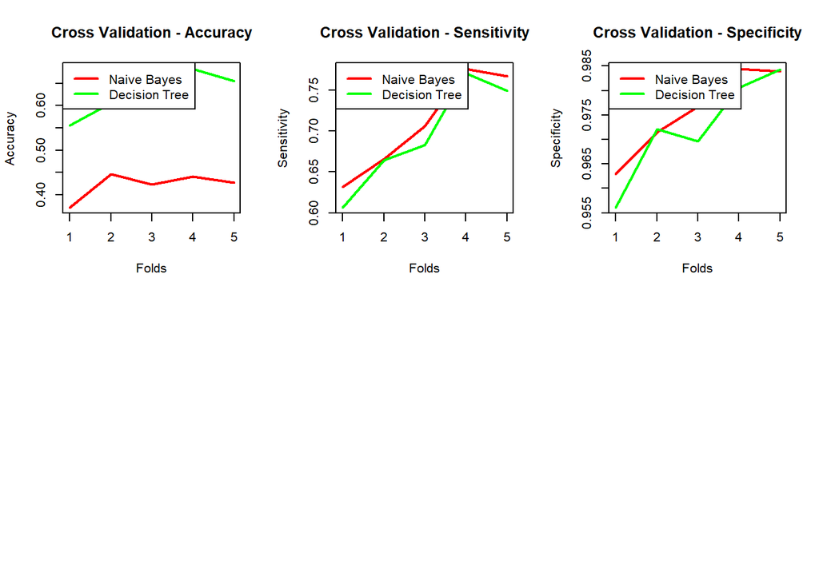

```r
#cross-validation accuracy plot
par(mfrow=c(2,3))
y<-list(resnb[1,1],resnb[2,1],resnb[3,1],resnb[4,1],resnb[5,1])
ynew<-list(resdec[1,1],resdec[2,1],resdec[3,1],resdec[4,1],resdec[5,1])
x<-list(1,2,3,4,5)
xaxis<-unlist(x)
accuracyplot<-plot(xaxis,unlist(y),type="l" ,lwd=2,col="red",xlab="Folds",ylab="Accuracy",ylim=range( c(y, ynew) ),main="Cross Validation - Accuracy")
lines(xaxis,unlist(ynew),type="l",lwd=2,col="green")
legend("topleft",
       legend = c("Naive Bayes", "Decision Tree"),lwd=2,col=c("red","green"))

#cross-validation sensitivity plot
y<-list(resnb[1,2],resnb[2,2],resnb[3,2],resnb[4,2],resnb[5,2])
ynew<-list(resdec[1,2],resdec[2,2],resdec[3,2],resdec[4,2],resdec[5,2])
x<-list(1,2,3,4,5)
xaxis<-unlist(x)
sensitivityplot<-plot(xaxis,unlist(y),type="l" ,lwd=2,col="red",xlab="Folds",ylab="Sensitivity",ylim=range( c(y, ynew) ),main="Cross Validation - Sensitivity")
lines(xaxis,unlist(ynew),type="l",lwd=2,col="green")
legend("topleft",
       legend = c("Naive Bayes", "Decision Tree"),lwd=2,col=c("red","green"))

#cross-validation specificity plot
y<-list(resnb[1,3],resnb[2,3],resnb[3,3],resnb[4,3],resnb[5,3])
ynew<-list(resdec[1,3],resdec[2,3],resdec[3,3],resdec[4,3],resdec[5,3])
x<-list(1,2,3,4,5)
xaxis<-unlist(x)
specificityplot<-plot(xaxis,unlist(y),type="l" ,lwd=2,col="red",xlab="Folds",ylab="Specificity",ylim=range( c(y, ynew) ),main="Cross Validation - Specificity")
lines(xaxis,unlist(ynew),type="l",lwd=2,col="green")
legend("topleft",
       legend = c("Naive Bayes", "Decision Tree"),lwd=2,col=c("red","green"))
```

## Classification **5) Naive Bayes**

```r
#hypertuning isn't recommended for naive bayes because the overall performance is affected by just one parameter i.e laplace
NBclassfier=naiveBayes(most_pref_shop ~., data=train,laplace=3)
print(NBclassfier)
```

```
##
## Naive Bayes Classifier for Discrete Predictors
##
## Call:
## naiveBayes.default(x = X, y = Y, laplace = laplace)
##
## A-priori probabilities:
## Y
##     shop_1     shop_2     shop_3     shop_4     shop_5
## 0.57251719 0.28963389 0.06522820 0.03690052 0.03572020
##
## Conditional probabilities:
##         distance_avg
## Y             [,1]      [,2]
##   shop_1 2228.2743 1081.1791
##   shop_2 2000.7533 1083.6497
##   shop_3 1140.8915  747.7287
##   shop_4 1134.4941  938.0551
##   shop_5  864.1363  747.9235
##
##         products_purchased_avg
## Y            [,1]      [,2]
##   shop_1 734.2576  983.3481
##   shop_2 983.7471 1220.5737
##   shop_3 865.3832 1025.0709
##   shop_4 701.4933 1151.5579
##   shop_5 735.1380 1005.2106
##
##         unique_products_purchased_avg
## Y            [,1]      [,2]
##   shop_1 153.4857 124.71988
##   shop_2 157.2487 114.48866
##   shop_3 121.4819  83.23778
##   shop_4 101.9433  91.71105
##   shop_5 106.8446  84.47690
##
##         product_price_avg
## Y            [,1]      [,2]
##   shop_1 4.183217 11.381002
##   shop_2 3.211099  7.564755
##   shop_3 2.706795  1.303107
##   shop_4 2.715958  1.713115
##   shop_5 2.611535  1.176166
##
##         amount_purchased_avg
## Y            [,1]      [,2]
##   shop_1 8.691842 12.115649
##   shop_2 9.342500  9.635068
##   shop_3 8.878031  5.950138
##   shop_4 8.093840  6.619375
##   shop_5 8.268035  6.120069
```

**6) Decision tree (rpart)**

```r
#hypertuning rpart
obj3 <- tune.rpart(most_pref_shop~., data =train, minsplit = c(5,10,15))
summary(obj3)
```

```
##
## Parameter tuning of 'rpart.wrapper':
##
## - sampling method: 10-fold cross validation
##
## - best parameters:
##  minsplit
##         5
##
## - best performance: 0.4039592
##
## - Detailed performance results:
##   minsplit     error dispersion
## 1        5 0.4039592  0.0106848
## 2       10 0.4039592  0.0106848
## 3       15 0.4039592  0.0106848
```

```r
#decision tree classifier
modelr<-rpart(most_pref_shop ~., data=train, method="class",control=rpart.control(cp=0.001))
print(modelr$cptable)
```

```
##             CP nsplit rel error    xerror        xstd
## 1  0.014483627      0 1.0000000 1.0000000 0.005266200
## 2  0.009494284      3 0.9464251 0.9487987 0.005226745
## 3  0.009009882      4 0.9369308 0.9423077 0.005220979
## 4  0.007266034      5 0.9279209 0.9405154 0.005219356
## 5  0.005062003      6 0.9206549 0.9263224 0.005206038
## 6  0.004359620      8 0.9105309 0.9203158 0.005200150
## 7  0.004214300      9 0.9061713 0.9176032 0.005197441
## 8  0.002664212     11 0.8977427 0.9162953 0.005196124
## 9  0.002567332     12 0.8950785 0.9103856 0.005190085
## 10 0.002470451     13 0.8925111 0.9097074 0.005189382
## 11 0.002082930     16 0.8850998 0.9005038 0.005179658
## 12 0.001533940     17 0.8830169 0.8935284 0.005172050
## 13 0.001513757     20 0.8784150 0.8899438 0.005168060
## 14 0.001501647     24 0.8723600 0.8899438 0.005168060
## 15 0.001404767     26 0.8693567 0.8884906 0.005166427
## 16 0.001146419     27 0.8679519 0.8856326 0.005163189
## 17 0.001065685     31 0.8631079 0.8812730 0.005158183
## 18 0.001000000     32 0.8620422 0.8791901 0.005155762
```

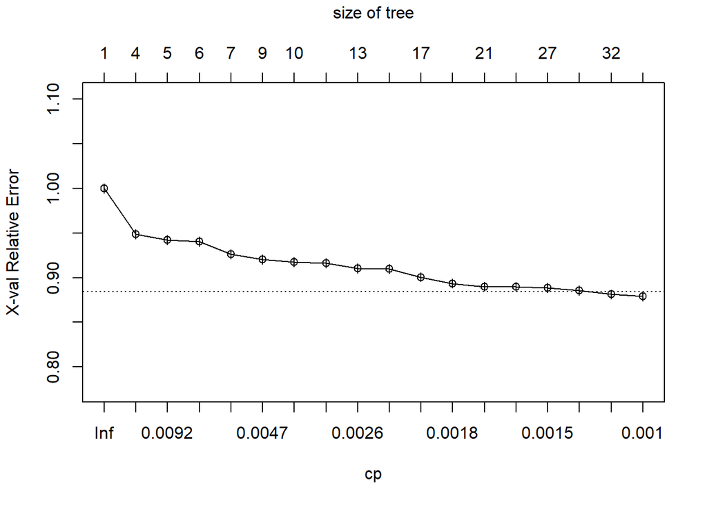

```r
plotcp(modelr)
```

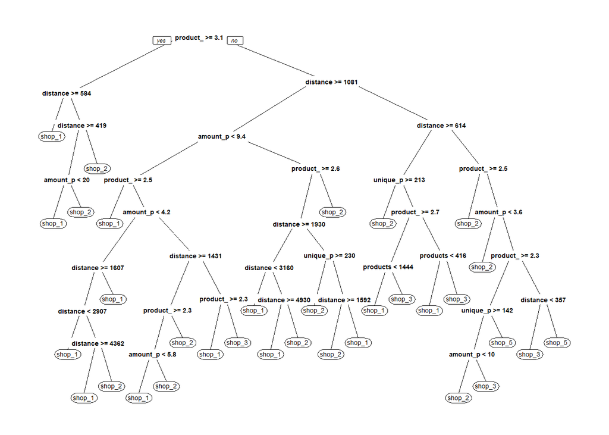

```r
prp(modelr)
```

```r
#the relative error is reduced but the graph is overplotted
modelr<-rpart(most_pref_shop ~., data=train, method="class",control=rpart.control(cp=0.0001))
print(modelr$cptable)
```

```
##              CP nsplit rel error    xerror        xstd
## 1  0.0144836272      0 1.0000000 1.0000000 0.005266200
## 2  0.0094942841      3 0.9464251 0.9478299 0.005225895
## 3  0.0090098818      4 0.9369308 0.9467642 0.005224956
## 4  0.0072660337      5 0.9279209 0.9392560 0.005218208
## 5  0.0050620035      6 0.9206549 0.9256927 0.005205428
## 6  0.0043596202      8 0.9105309 0.9200252 0.005199861
## 7  0.0042142996      9 0.9061713 0.9180391 0.005197879
## 8  0.0026642124     11 0.8977427 0.9170703 0.005196906
## 9  0.0025673319     12 0.8950785 0.9086902 0.005188325
## 10 0.0024704515     13 0.8925111 0.9086902 0.005188325
## 11 0.0020829297     16 0.8850998 0.9003585 0.005179502
## 12 0.0015339405     17 0.8830169 0.8885390 0.005166482
## 13 0.0015137570     20 0.8784150 0.8856811 0.005163244
## 14 0.0015016470     24 0.8723600 0.8856811 0.005163244
```

[output cut: 53 more lines]

**Conclusion:** By considering the features distance_avg,products_purchased_avg,unique_products_purchased_avg,product_price_Avg, amount_purchased_Avg, most preferred shop is calculated and the above mentioned classification algorithms are applied.This will further help in predicting which shop the customer would choose